# 360° – Crown of India

2025

[Crown of India](https://restaurantguru.com/Crown-of-India-Maur)

Valentinstag-Special

[Christmas Menü](https://www.restaurant-crown-of-india.ch/wp-content/uploads/2024/12/2024_Crown-of-India_Christmas.jpg)

[Silvester Buffet](https://www.restaurant-crown-of-india.ch/wp-content/uploads/2024/12/2024_Crown-of-india_Silvester.jpg)

2025

[Crown of India](https://restaurantguru.com/Crown-of-India-Maur)

## 360°

#### **Ansicht in 360°**

[interactive chart not shown]

# Valentinstag-Special

**Liebe Gäste,**

wir laden Sie herzlich, am **14. Februar ab 18 Uhr** an unserem exquisiten Abend-Buffet teilzunehmen und die Vielfalt der indischen Küche zu entdecken. Geniessen Sie einen unvergesslichen Abend in unserem Restaurant!

Geniessen Sie warme und kalte indische Gerichte à discretion an unserem

# **Valentine’s Day Buffet**

**49,50 SFr. pro Person**

**Inklusive Welcome Drinks**

Wir freuen uns auf Ihren Besuch  
Jeder ist Herzlich willkommen!

**[Reservieren Sie noch heute.](https://www.restaurant-crown-of-india.ch/reservieren/)**

Indisches 3-Gang-Menü  
am Valentinstag!

**Für 2 Personen 99 Sfr.**

*Liebe Gäste,*  
wir laden Sie herzlich, am **14. Februar ab 18 Uhr** an unserem Exquisiten 3-Gang-Menü teilzunehmen und die Vielfalt der indischen Küche zu entdecken. Geniessen Sie einen unvergesslichen Abend in unserem Restaurant!

**1. Gang:**  
Vorspeisen-Auswahl

**2. Gang:**  
Verschiedene Hauptgerichte, darunter köstliche vegetarische, Fleisch- und Fischgerichte

**3. Gang:**  
Auswahl an verführerischen Desserts

**Inklusive Welcome Drinks**

Wir freuen uns auf Ihren Besuch  
Jeder ist Herzlich willkommen!

[Reservieren Sie noch heute.](https://www.restaurant-crown-of-india.ch/reservieren/)  
Wir freuen uns auf Sie!

#### Telefonische Reservierung:

##### **+41 (0) 43 499 0202** **+41 (0) 79 625 9113**

#### **[Online-Reservierung](https://www.restaurant-crown-of-india.ch/reservieren/)**

# Christmas Menu

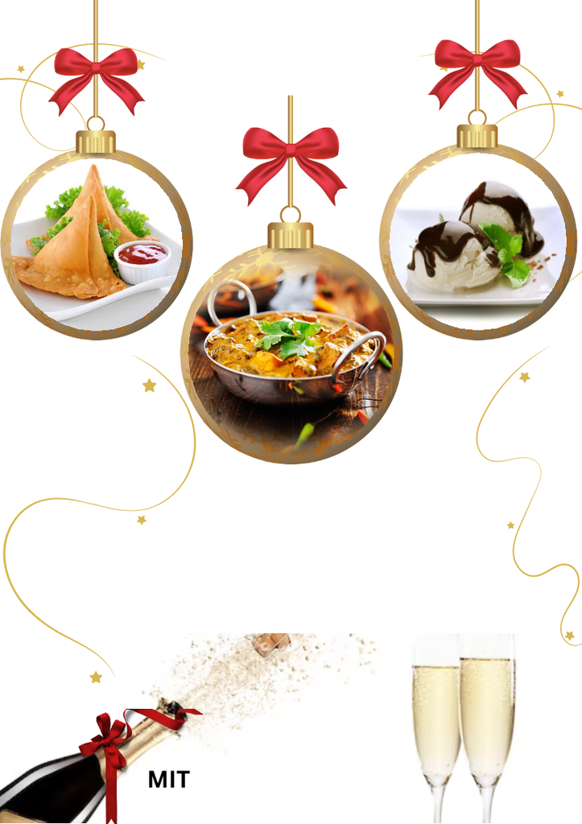

CHRISTMAS

Menu

DESSERTS

VORSPEISE

HAUPTGANG

WEIHNACHTSEMPFEHLUNG

RECOMMENDATION FINE INDIAN CUISINE

LIEBE GÄSTE,

UNSER KÜCHENCHEF UND SEIN TEAM WÜRDEN SIE

GERNE MIT EINEM MENÜ VERWÖHNEN

UNSER SERVICETEAM INFORMIERT SIE

ÜBER DAS 3–GANG MENÜ

99. 50Fr

WELCOME DRINK

**Christmas-****Menu**

Zum **Weihnachtfest** verwöhnt  
Sie unser Küchenchef  
mit einem spezielles  
3-Gang-Menü inkl.  
Begrüssungsgetränk  
für 2 Personen für nur 99.50 SFr.

**[Reservieren Sie noch heute.](https://www.restaurant-crown-of-india.ch/reservieren/)**  
Wir freuen uns auf Sie!